# RMarkdown: верстаем красивое

Антон Ангельгардт

**RMarkdown** — это пакет, который позволяет соединять текст, исполняемый код и результаты исполнения кода в единый документ. Это очень полезно для представления данных. На выходе мы можем получить файлы `.html`, `.pdf` — в том числе презентации форматов `.html` и `.pdf`[^1] — `.docx`, `.pptx`. Более того, можно связать несколько HTML-документов и получить сайт или книгу. Ну, гениально же!

Мы сосредоточимся на HTML-документах сегодня, потому что это проще всего и, как показывает практика, полезнее всего.

## Установка

> Если вдруг ещё не, надо поставить R ([Win](https://cran.r-project.org/bin/windows/base/), [Mac](https://cran.r-project.org/bin/macosx/), [Linux](https://cran.rstudio.com/bin/linux/)) и [RStudio](https://www.rstudio.com/products/rstudio/download/).

Устанавливается RMarkdown как обычный пакет:

```r
install.packages("rmarkdown")
```

Есть ещё пакет, который не обязательно устанавливать сразу, но он нам пригодится, чтобы делать красивое:

```r
install.packages("prettydoc")
```

## Структура документа

- YAML-шапка
- самый обычный текст (как в блокноте) с форматированием от Markdown, расширенным с помощью Pandoc
- блоки кода (в целом, на любом языке программирования)
- формулы в $\LaTeX$’e

### Чё внутри происходит?

Кратко взглянем на то, как из `.rmd` получается `.html`.

1. Мы пишем руками `.rmd.`шку (RMarkdown).
2. Отправляем её пакету `knitr`, который выполняет чанки кода и делаем `.md`шку (Markdown).
3. Дальше `.md`шку берёт Pandoc, который есть конвертер, и делает окончательный файл, который мы пожелали — например, `html`ку или `.pdf.`ку, призывая $\LaTeX$.

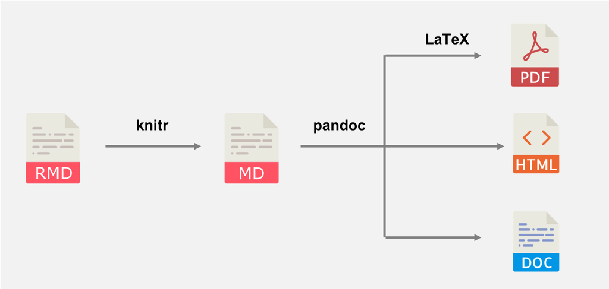

[Источник](https://bookdown.org/yihui/rmarkdown-cookbook/rmarkdown-process.html)

### Первый `.rmd`-файл

Как создать `.rmd`шку? Надо проследовать по пути `File > New File > RMarkdown...`, оставить все настройки по умолчанию и жмакнуть `OK`.

[figure not shown]

Возникнет дефолтный `.rmd`-файл.

Его можно скомпилировать либо с помощью функции `rmarkdown::render("file.Rmd")`, либо жмакнув кнопку `Knit` вверху текстового редактора.

[figure not shown]

Создайте и скомпилируйте дефолтный `.rmd`-файл.

## Markdown & Pandoc

- Markdown — это универсальный язык разметки, использующийся очень много где.
- Pandoc — конвертер файлов между различными форматами. А ещё он дает немного плюшек для форматирования (индексы, нумерованные примеры, сноски).

### Заголовки

Обозначаются хэштегами, после которых надо обязательно поставить пробел, иначе получится ссылка.

```
# Заголовок 1

## Заголовок 2

### Заголовок 3

#### Заголовок 4

##### Заголовок 5

###### Заголовок 6
```

На заголовках можно оставлять теги — они не отображаются — чтобы организовывать навигацию по документу:

```
# Заголовок 1 {#tag1}

## Заголовок 2 {#header2}

### Заголовок 3 {#wow_third_level_header}
```

### Форматирование

- *Курсив / наклон* — `*курсив* или _курсив_`
- **Полужирный** — `**полужирный** или __полужирный__`
- Зачеркнутый — `~~зачеркнутый~~`

### Списки

Есть несколько вариантов и все рабочие:

#### Ненумерованные списки

```
* овощи
    * томаты
    * все остальные
* фрукты
    * обыкновенные
        * яблоко
        * груша
    * тропические
        * папайя
        * маракуйя
* ягоды
    * удобные для сбора
    * крыжовник
```

- овощи
  - томаты
  - все остальные
- фрукты
  - обыкновенные
    - яблоко
    - груша
  - тропические
    - папайя
    - маракуйя
- ягоды
  - удобные для сбора
  - крыжовник

Ещё можно плюсами и минусами пользоваться, типа вот так

```
- овощи
    + томаты
    + все остальные
- фрукты
    + обыкновенные
        - яблоко
        - груша
    + тропические
        - папайя
        - маракуйя
- ягоды
    - удобные для сбора
    - крыжовник
```

- овощи
  - томаты
  - все остальные
- фрукты
  - обыкновенные
    - яблоко
    - груша
  - тропические
    - папайя
    - маракуйя
- ягоды
  - удобные для сбора
  - крыжовник

#### Нумерованные списки

```
1. рыба
   1. карп
   3. треска
   2. камбала
2. мясо
    1. всякое
    2. разное
3. ни рыба ни мясо
   1. птица
      1. кура
      4. перепёлка
   2. инопланетное непонятно что
```

1. рыба
   1. карп
   2. треска
   3. камбала
2. мясо
   1. всякое
   2. разное
3. ни рыба ни мясо
   1. птица
      1. кура
      2. перепёлка
   2. инопланетное непонятно что

Смотрите, даже если мы накосячили в нумерации, при компиляции всё поправилось, и нумерация в итоговом доке верная.

### Нумерованные примеры

В списки можно собирать некоторые примеры:

```
(@) Парменид сказал, что «бытие есть --- небытия нет». Трудно поспорить.
(@socrates) Сократ заявил, что он «знает, что ничего не знает, но другие не знают даже этого». Ну, ок.
(@plato) Платон задвигал про мир идей.
(@aristotle) Аристотель нам основал все науки.
```

1. Парменид сказал, что «бытие есть — небытия нет». Трудно поспорить.
2. Сократ заявил, что он «знает, что ничего не знает, но другие не знают даже этого». Ну, ок.
3. Платон задвигал про мир идей.
4. Аристотель нам основал все науки.

Во-вервых, они будут автоматически нумероваться, а во-вторых, если к ним приписать лейблы (здесь: `socrates`, `plato`, `arislotle`). Можно будет ссылаться на примеры:

```
Считается, что (@plato) записывал за (@socrates).
```

Считается, что (3) записывал за (2).

### Ссылки

Вариантов есть несколько и вот они, пожалуй, все.

```
Вставляем [ссылку](https://www.google.com/) красиво.

Или не очень красиво, но зато ясно, куда она ведет: <https://www.google.com/>.

Если хочется собрать все ссылки в одном месте, то для отображения их в тексте можно оставить [метку][1] или даже просто [метку].

А ещё если у вас есть теги на заголовках, можно ссылаться и внутрь документа, например [так](#tables).

[1]: https://www.google.com/
[метку]: https://www.google.com/
```

Вставляем [ссылку](https://www.google.com/) красиво.

Или не очень красиво, но зато ясно, куда она ведет: https://www.google.com/.

Если хочется собрать все ссылки в одном месте, то для отображения их в тексте можно оставить [метку](https://www.google.com/) или даже просто [метку](https://www.google.com/).

А ещё если у вас есть теги на заголовках, можно ссылаться и внутрь документа, например так.

### Картинки

Очень похожи по синтаксису на ссылки, только перед квадратными скобками надо поставить `!`,а внутри них пишется либо ничего, либо [альтернативный текст](https://en.wikipedia.org/wiki/Alt_attribute)/название картинки. В круглых скобках пишется адрес картинки.

```
![](cat.jpeg)
![Удивлённый кот Федя](https://cdnn21.img.ria.ru/images/07e5/06/18/1738448523_0:54:864:540_640x0_80_0_0_1909d455bf858de749abb1ae8dc540b7.jpg.webp)
```

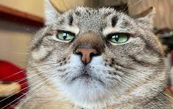

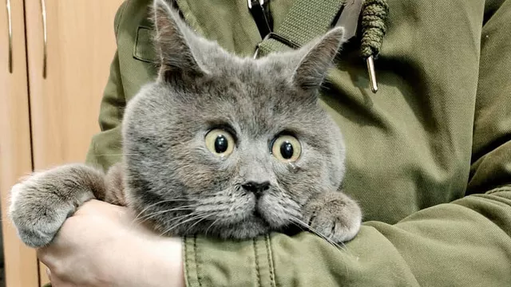

Да, прямо веб-ссылку можно впихнуть туда.

```
Метки здесь так же работают. ![][cat_shocked]

[cat_shocked]: cat_shocked.png
```

Метки здесь также работают.

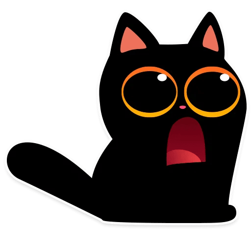

Лично я не большой фанат вставлять картинки средствами Markdown, поэтому использую HTML. Там больше возможностей кастомизации отображения.

### Цитаты

Цитаты оформляются с помощью знака `>`:

```
> Это цитата, которая содержит глубокую философскую мысль.
> Тут мысль раскрывается --- это строка попадает в тот же фрагмент.

> А это уже _следующая_ цитата, в которой применяется __форматирование__.
>
> <p align="right">Автор цитаты</p>
```

> Это цитата, которая содержит глубокую философскую мысль. Тут мысль раскрывается — это строка попадает в тот же фрагмент.

> А это уже *следующая* цитата, в которой применяется **форматирование**.

> Автор цитаты[^2]

### Таблицы

Делать руками таблицы — достаточно запарно. В общем-то, не только в Markdown, но и в HTML или $\LaTeX$ тоже. К тому же, не то чтобы нам очень часто надо делать таблицы руками. Поэтому не будем тратить на это много времени и внимания, и просто сохраним [ссылку на генератор таблиц](http://www.tablesgenerator.com/markdown_tables).

### Сноски

Делаются так:

```
Это сноска[^1].
Но лучше не номером, а как-то так[^another_footnote].

[^1]: Да, это сноска.
[^another_footnote]: Да, это тоже сноска, только не по номеру, а через лейбл.
```

Это сноска[^3]. Но лучше не номером, а как-то так[^4].

Разницы, где оставлять содержание сноски, особой нет — можно сразу после абзаца, в котором сноска даётся, можно в конце документа.

Я предпочитаю первый вариант, чтобы можно было следовать за содержанием документа и не прыгать по нему, если нужны исправления.

Представим, что вам пора писать статью. Создайте шаблон для неё в RMarkdown.

Шаблон должен содержать:

- заголовки основных разделов
- пара строк текста в каждом разделе, о чем будет этот раздел
- суперважная сноска в каком-нибудь из разделов
- ссылка на какой-то внешний ресурс (например, откуда вы взяли стимульный материал)
- цитата великого ученого, на работы которого вы опираетесь

## HTML

Ежели вы монстр и постигли HTML, то можно прям на нём делать вставки в RMarkdown. Ну, скажем, список можно сделать и так:

```
<ul>
    <li>пункт номер раз</li>
    <li>пункт номер два</li>
    <li>пункт номер три</li>
</ul>
```

- пункт номер раз
- пункт номер два
- пункт номер три

Кстати, HTML и Markdown можно комбинировать, и это будет работать:

```
Допустим,
<dl>
   <dt>__термин__</dt>
   <dd> и его определение, в котором нужно сделать _акцент_, либо <em>акцент</em>.</dd>
</dl>
```

Допустим,

**термин**

и его определение, в котором нужно сделать *акцент*, либо *акцент*.

## $\LaTeX$

С помощью $\LaTeX$’а можно писать красивые формулы. Хорошо, конечно, если вы шарите за $\LaTeX$, но если нет, можно посмотреть 100500 примеров [тут](http://www.ccas.ru/voron/download/voron05latex.pdf).

### Сверхкраткое введение в математику в $\LaTeX$’е

- Есть формулы. Они бывают *внутритекстовые*, которые — шок! — идут внутри текста, и *выключные*, которые вынесены в отдельную строку.
- Внтуритекстовые формулы оформляются с помощью одинарных знаков доллара `$ formula $` примерно так:

```
Если верить тому, что $2 + 2 = 4$, то получается, что $22 + 22 = 44$.
```

Если верить тому, что $2 + 2 = 4$, то получается, что $22 + 22 = 44$.

- Выключные формулы оформляются с помощью двойных знаков доллара `$$ formula $$`. Они всегда выравнены по центру.

```
Кажется, что если сложить несколько чисел и поделить на их количество, получится нечто, именуемое _средним арифметическим_:

$$
\bar x = \frac{1}{n} \sum_{i=1}^n x_i
$$

Будем думать, что это действительно так.
```

Кажется, что если сложить несколько чисел и поделить на их количество, получится нечто, именуемое *средним арифметическим*:

$$\bar x = \frac{1}{n} \sum_{i=1}^n x_i$$

Будем думать, что это действительно так.

- Есть куча разных операторов-функций типа `\bar`, `\sum`, `\frac`, `\times` и др. Они позволяют вводить всякие разные математические символы. Какие они есть и как их употреблять, можно опять же смотреть [тут](http://www.ccas.ru/voron/download/voron05latex.pdf).

## Код

Код заключается в бэктики: `` `sum(1, 2, 3)` ``. Это если мы хотим код прямо в строке. Если хотим код отдельным чанком, то по три бэктика в начале и конце:

````
```
x <- c(1,3,5,7)
mean(x)
```
````

Правда такие чанки кода не исполняются. Нам такого не надо. Чтобы исполнить код при компиляции файла, надо указать, на каком языке мы написали заклинания.

### Языки программирования

Это указывается после первых бэктиков (допустим, мы почему-то пишем на R):

````
```{r}
x <- c(1,3,5,7)
mean(x)
```
````

```r
x <- c(1,3,5,7)
mean(x)
```

```
## [1] 4
```

Можно сделать и питон:

````
```{python}
spisok = ["where", "is", "my", "beer"]
for word in spisok:
    print(word)
```
````

[output not shown]

### Настройка чанков

### Именование чанков

## YAML-шапка

### Оглавление

Есть несколько атрибутов, которые позволяют задать оформление оглавления:

- `toc` — вставлять ли оглавление финальный док
- `toc_depth` — сколько уровней иерархии отображать в оглавлении
- `toc_float` — должно ли оглавление все время следовать за текстом
- `collapsed` — должно ли оглавление быть все время полностью раскрыто
- `number_sections` — автоматическая нумерация секций
- `code_folding (hide)` — делать ли кнопочку, показывающую/скрывающую весь код
- `theme` — одна из Bootstrap тем highlight: “default”, “tango”, “pygments”, “kate”, “monochrome”, “espresso”, “zenburn”, “haddock” или “textmate”

### Отображение датафреймов

## Дизигн

### Макеты с темами

Мы в самом начале установили пакет `prettydoc`, который содержит в себе весьма pretty темы для RMarkdown-документов.

## Куда заливать HTML?

## Что ещё?

Представление данных, конечно, не ограничивается RMarkdown. Вот некоторые штуки, которые также могут быть полезны:

- `bookdown` — расширение RMarkdown для написания книг, диссера, создания перезентаций и т.д.
- `shiny` — динамические сайты, на которых можно развернуть взамодействие с пользователем
- `flexdashboard` — динамические дэшборды
- `posterdown` — постеры в RMarkdown
- `pagedown` — тут много всяких шаблонов примерно для всего (от книги, статьи и резюме до приглашения на свадьбу)
- `blogdown` — сайты можно пилить
[^1]: Потребуется Beamer
[^2]: Здесь использован HTML-тег `p` для того, чтобы сделать выравнивание имени автора по правому краю. К сожалению, сам Markdown про выравнивание ничего не знает :(
[^3]: Да, это сноска.
[^4]: Да, это тоже сноска, только не по номеру, а через лейбл.